# FastQ exercises

Rockefeller University, Bioinformatics Resource Centre

https://rockefelleruniversity.github.io/Bioconductor_Introduction/

These are answers for exercises that cover the FastQ sections of [Introduction to Bioconductor](https://rockefelleruniversity.github.io/Bioconductor_Introduction/).

## FastQs and ShortRead

In these exercises we will review some of the **ShortRead** packages functionality with handling fastQ files.

The example data can be found in the data directory.

**data/heart.bodyMap.fq**

1. Plot the occurrence of A, G, T, C and N in the read with ID **“HWI-BRUNOP16X_0001:7:66:3246:157000#0/1”** using ggplot2

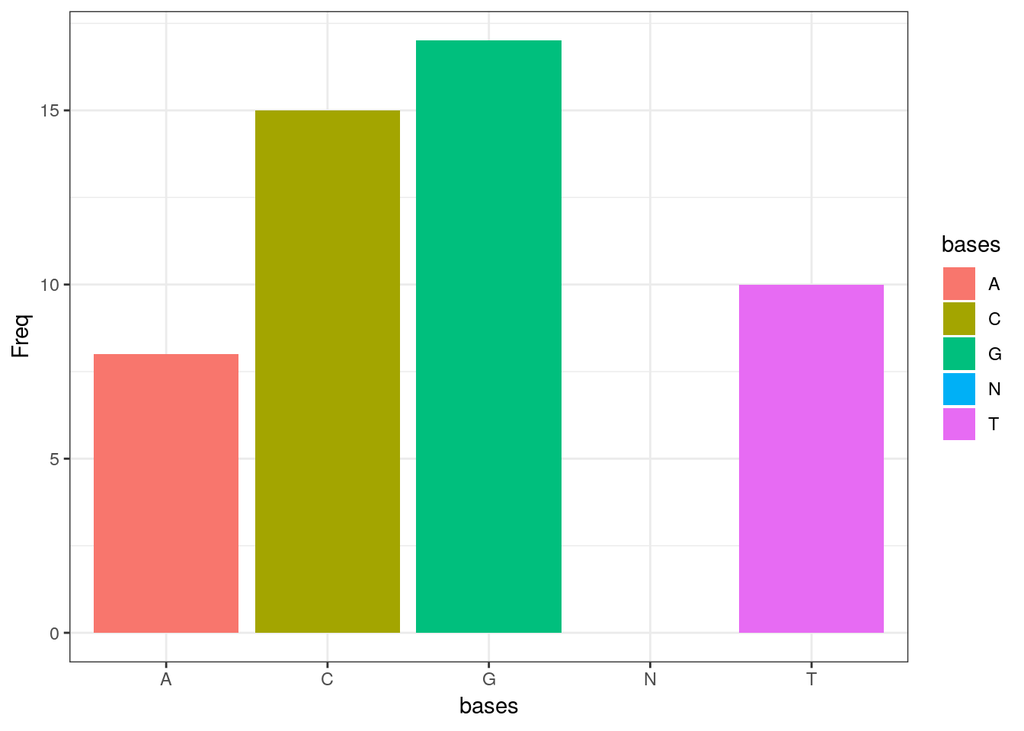

```r
library(ShortRead)
FileName <- "data/heart.bodyMap.fq"
my_fastq <- readFastq(FileName)
fastqRead <- my_fastq[as.character(id(my_fastq)) == "HWI-BRUNOP16X_0001:7:66:3246:157000#0/1"]
fastqReadSeq <- sread(fastqRead)
alpFreq <- alphabetFrequency(fastqReadSeq)
alpFreq5 <- alpFreq[,c("A","C","G","T","N")]
toPlot <- data.frame(bases=names(alpFreq5),Freq=alpFreq5)
library(ggplot2)
ggplot(toPlot,aes(x=bases,y=Freq,fill=bases))+geom_bar(stat="identity") + theme_bw()
```

2. Create a boxplot of quality scores over cycles for first 10,000 reads using base graphics.

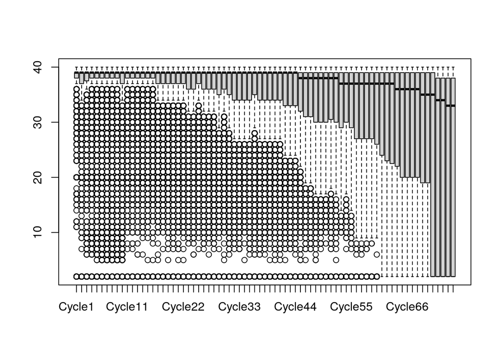

```r
allQuals <- quality(my_fastq[1:10000,])
forBox <- as(allQuals,"matrix")
colnames(forBox) <- paste0("Cycle",1:ncol(forBox))
boxplot(forBox)
```

3. Plot the frequency of A, G, C, T and N bases over cycles using ggplot2.

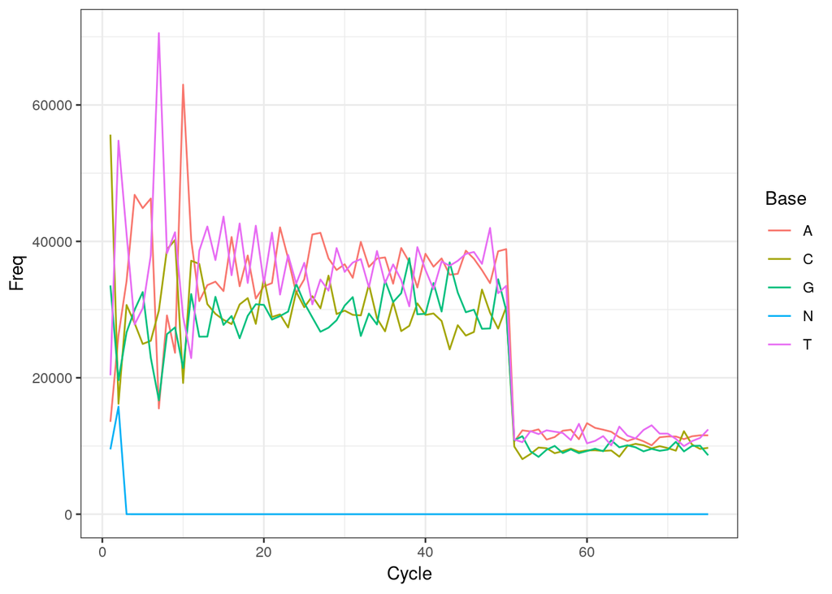

```r
alpByCyle <- alphabetByCycle(sread(my_fastq))
alpByCyleFilt <-  alpByCyle[c("A","G","C","T","N"),]
AbyCycFrame <- data.frame(Base="A",Freq=alpByCyleFilt["A",],Cycle=1:75)
CbyCycFrame <- data.frame(Base="C",Freq=alpByCyleFilt["C",],Cycle=1:75)
TbyCycFrame <- data.frame(Base="T",Freq=alpByCyleFilt["T",],Cycle=1:75)
GbyCycFrame <- data.frame(Base="G",Freq=alpByCyleFilt["G",],Cycle=1:75)
NbyCycFrame <- data.frame(Base="N",Freq=alpByCyleFilt["N",],Cycle=1:75)
myFrame <- rbind(AbyCycFrame,CbyCycFrame,TbyCycFrame,GbyCycFrame,NbyCycFrame)
ggplot(myFrame,aes(x=Cycle,y=Freq,colour=Base))+geom_line()+theme_bw()
```

4. How many reads are in the original fastq? Read in a random 10000 bases from the original fastq.

```r
length(my_fastq)
```

```
## [1] 132604
```

```r
mySampledFile <- FastqSampler("data/heart.bodyMap.fq",n=10000)
my_fastq_10000 <- yield(mySampledFile)
my_fastq_10000
```

```
## class: ShortReadQ
## length: 10000 reads; width: 50 75 cycles
```

```r
dupLogical <- srduplicated(my_fastq_10000)
numberOfDups <- table(dupLogical)
numberOfDups
```

```
## dupLogical
## FALSE  TRUE
##  4010  5990
```

```r
nonDups <- my_fastq_10000[dupLogical]
```

```r
trimmedNonDups <- trimTails(nonDups,10,"5")
```

7. Plot a histogram of the resulting read lengths using base graphics

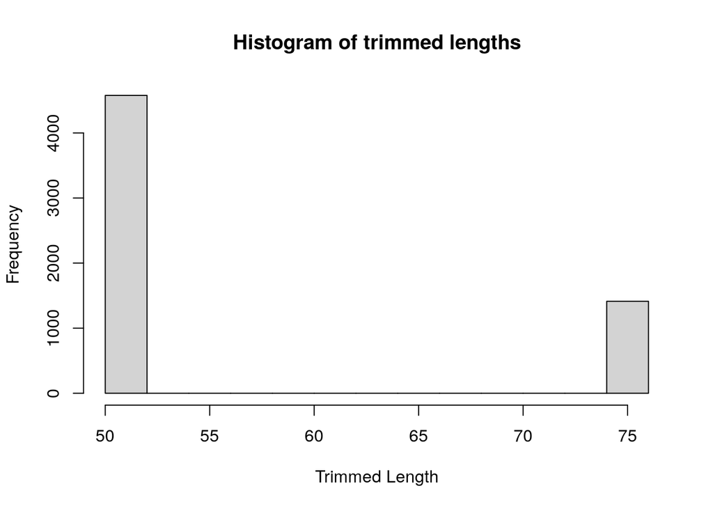

```r
hist(width(trimmedNonDups),xlab="Trimmed Length",main="Histogram of trimmed lengths")
```

8.Filter out reads less than 32 bases and write to file

```r
filteredFastq <- trimmedNonDups[width(trimmedNonDups) >= 32]
writeFastq(filteredFastq,file="filteredFastq.fq.gz")
```

```r
unlink("filteredFastq.fq.gz")
```